# Modelagem Estatística de Dados

Houston Santos

27 October, 2024

O Conjunto de [**dados**](http://users.stat.ufl.edu/~winner/datasets.html) contém informações sobre o número de espécies em 42 ilhas britânicas. Vamos ter como variáveis: *área*, *elevação*, *número de tipos de solo*, *latitude* e *distância da Grã-Bretanha*. O obejtiso será realizar uma modelagem estatística dos dados e utilizando **Regressão Liner Multipla** prever o número de espécies.

Variáveis:

- `island`: nome da Ilha.
- `area`: área (km²).
- `elevation`: elevação máx. em metros.
- `number_of_soil_types`: número de tipos de solo.
- `latitude`: latitude (ponto médio do intervalo de latitudes em graus norte).
- `distance_from_britain`: distância da Grã-Bretanha (km).
- `number_of_species`: número de espécies.

```r
# Importando libs
library(dplyr)
library(glmnet)
library(tidyverse)
library(ggcorrplot)
```

# Análise Exploratória

## Importação dos Dados

```r
# Importando dados
url <- "https://users.stat.ufl.edu/~winner/data/britain_species.dat"
dados <- read.table(url, header = FALSE, sep = "", fill = TRUE)

# Renomear as colunas com nomes mais significativos
colnames(dados) <- c("island", "area", "elevation", "number_of_soil_types", "latitude", "distance_from_britain", "number_of_species")

# Verificar os dados modificados
dados
```

| island | area | elevation | number_of_soil_types | latitude | distance_from_britain | number_of_species |
| --- | --- | --- | --- | --- | --- | --- |
| Ailsa | 0.8 | 340.0 | 1 | 55.3 | 14.0 | 75.0 |
| Anglesey | 712.5 | 127.0 | 3 | 53.3 | 0.2 | 855.0 |
| Arran | 429.4 | 874.0 | 4 | 55.6 | 5.2 | 577.0 |
| Barra | 18.4 | 384.0 | 2 | 57.0 | 77.4 | 409.0 |
| Bressay | 31.1 | 226.0 | 1 | 60.1 | 201.6 | 177.0 |
| Britain | 229849.8 | 1343.0 | 16 | 54.3 | 0.0 | 1666.0 |
| Canna | 12.7 | 210.0 | 1 | 57.1 | 40.6 | 300.0 |
| Coll | 74.1 | 103.0 | 3 | 56.6 | 14.5 | 443.0 |
| Colonsay | 44.8 | 143.0 | 1 | 56.1 | 31.1 | 482.0 |
| Eigg | 29.0 | 393.0 | 1 | 56.9 | 12.3 | 453.0 |

[output cut: 36 more lines]

## Preprocessamento do Dados

Utilizando o pacote *tidyverse* para excluir valores NA, na importação dos dados a coluna **area** ficou como texto, filtra valores em **number_of_soil_types** este filtro será aplica para uma única observação bem discrepante.

```r
# Filtrando valor, tranformando coluna em numérico e retirando NA
dados <- dados %>%
  select(-island) %>%
  filter(number_of_soil_types <= 16) %>%
  mutate(area = as.numeric(area)) %>%
  filter(area < 200000.0) %>%
  drop_na()
```

## Análise Gráfica dos dados

### Dispersão de preditoras.

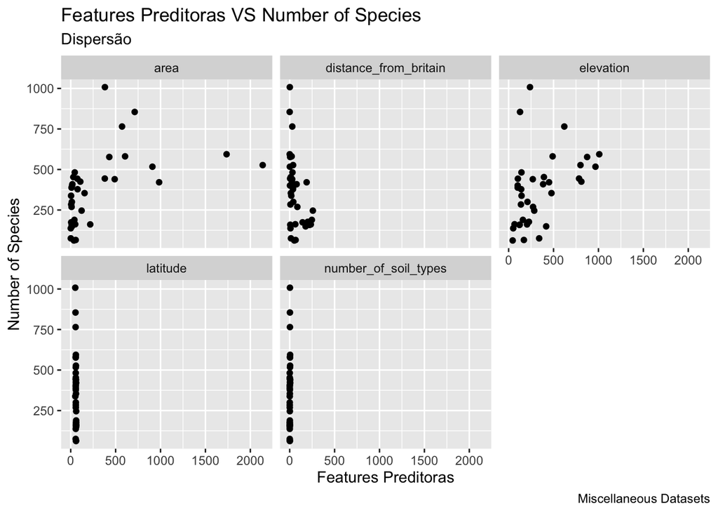

```r
# Gráfico de dispersão dos dados em relação a y
dados %>%
  pivot_longer(cols = c(area, elevation, number_of_soil_types, latitude, distance_from_britain),
               names_to = "variavel_x", values_to = "valor_x") %>%
  ggplot(aes(x = valor_x, y = number_of_species)) +
  geom_point() +
  facet_wrap(~ variavel_x, ncol = 3) +
  labs(
    title = "Features Preditoras VS Number of Species",
    subtitle = "Dispersão",
    x = "Features Preditoras",
    y = "Number of Species",
    caption = "Miscellaneous Datasets"
  )
```

### Latitude vs Number of Species

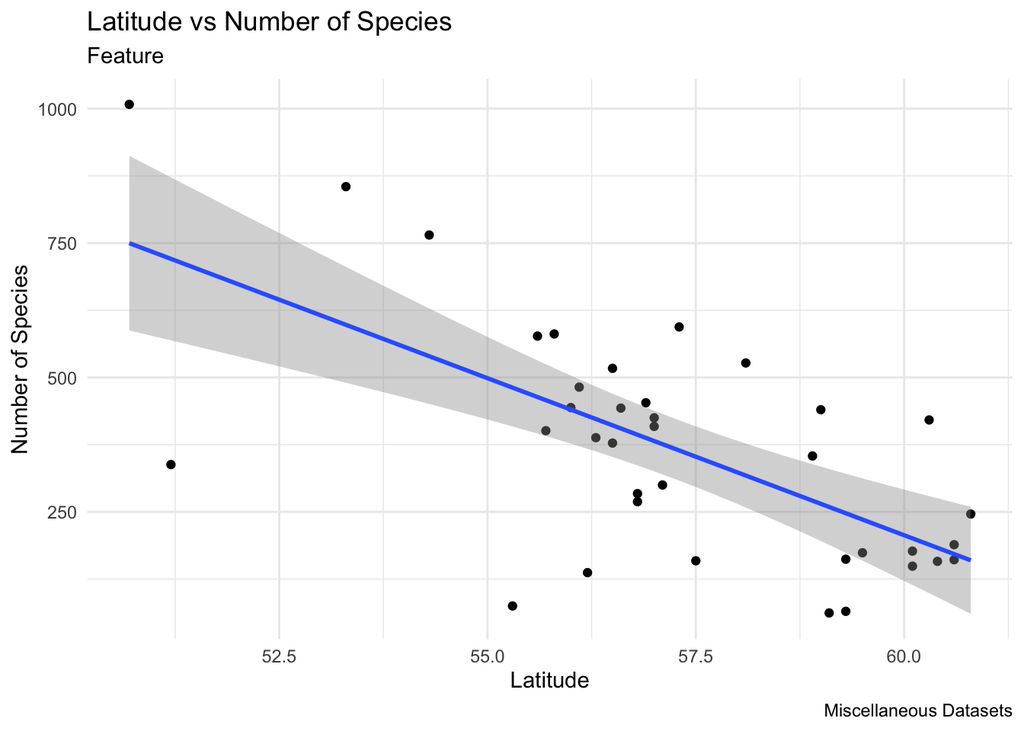

```r
# Dipersão de latitude vs number_of_species
dados %>%
  ggplot(aes(x = latitude, y = number_of_species)) +
  geom_point() +
  geom_smooth(method = "lm") +
  labs(
    title = "Latitude vs Number of Species",
    subtitle = "Feature",
    x = "Latitude",
    y = "Number of Species",
    caption = "Miscellaneous Datasets"
  ) +
  theme_minimal()
```

### Elevation vs Number of Species

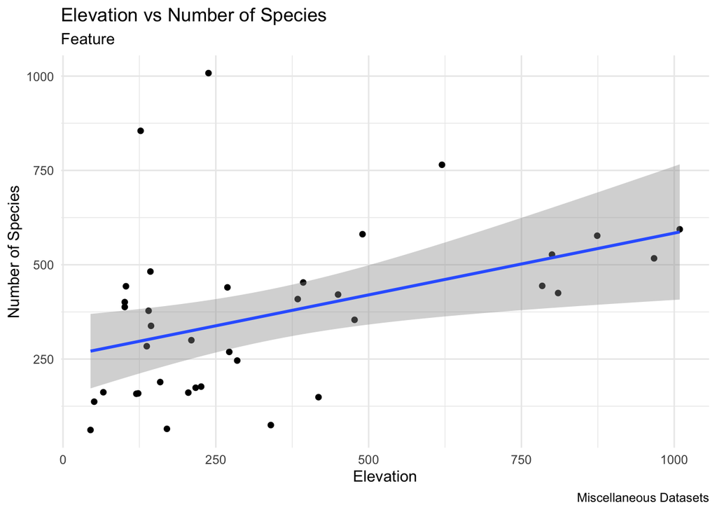

```r
# Dipersão de elevation vs number_of_species
dados %>%
  ggplot(aes(x = elevation, y = number_of_species)) +
  geom_point() +
  geom_smooth(method = "lm") +
  labs(
    title = "Elevation vs Number of Species",
    subtitle = "Feature",
    x = "Elevation",
    y = "Number of Species",
    caption = "Miscellaneous Datasets"
  ) +
  theme_minimal()
```

### Distance from Britain vs Number of Species

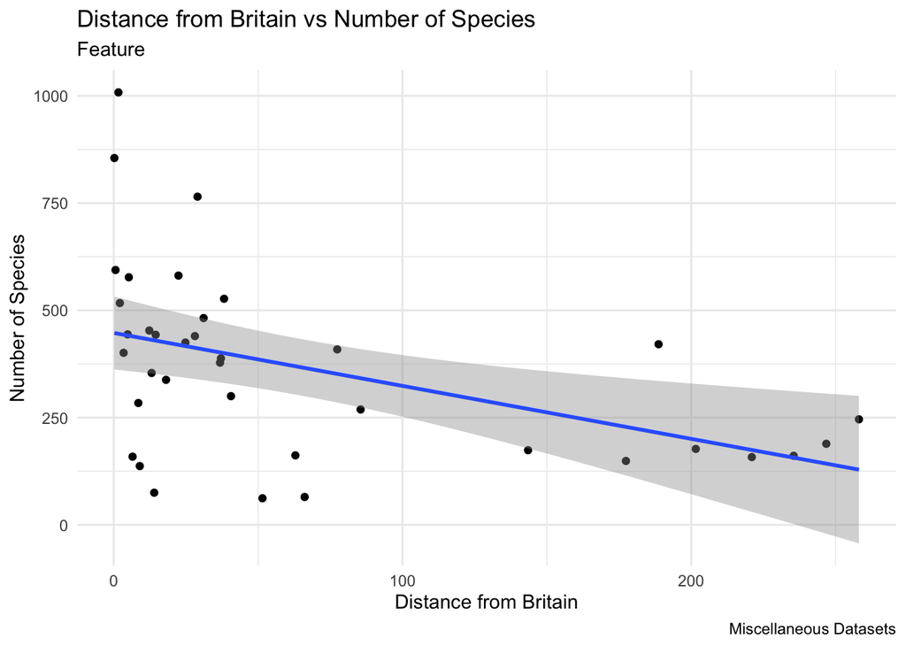

```r
# Dipersão de distance_from_britain vs number_of_species
dados %>%
  ggplot(aes(x = distance_from_britain, y = number_of_species)) +
  geom_point() +
  geom_smooth(method = "lm") +
  labs(
    title = "Distance from Britain vs Number of Species",
    subtitle = "Feature",
    x = "Distance from Britain",
    y = "Number of Species",
    caption = "Miscellaneous Datasets"
  ) +
  theme_minimal()
```

### Area vs Number of Species

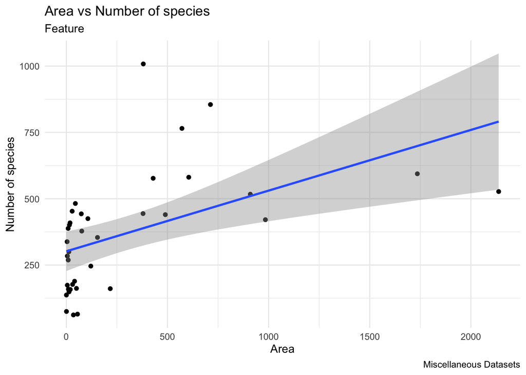

```r
# Dipersão de Area vs number_of_species
dados %>%
  ggplot(aes(x = area, y = number_of_species)) +
  geom_point() +
  geom_smooth(method = "lm") +
  labs(
    title = "Area vs Number of species",
    subtitle = "Feature",
    x = "Area",
    y = "Number of species",
    caption = "Miscellaneous Datasets"
  ) +
  theme_minimal()
```

### Number of Soil Types vs Number of Species

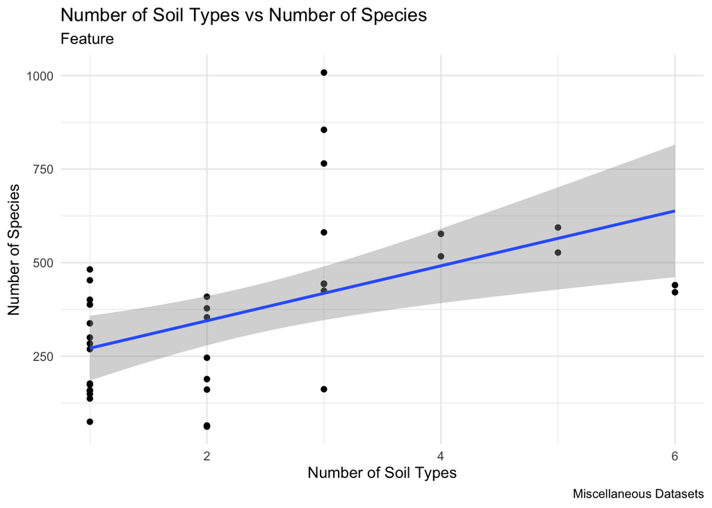

```r
# Dipersão de number_of_soil_types vs number_of_species
dados %>%
  ggplot(aes(x = number_of_soil_types, y = number_of_species)) +
  geom_point() +
  geom_smooth(method = "lm") +
  labs(
    title = "Number of Soil Types vs Number of Species",
    subtitle = "Feature",
    x = "Number of Soil Types",
    y = "Number of Species",
    caption = "Miscellaneous Datasets"
  ) +
  theme_minimal()
```

### Corelação

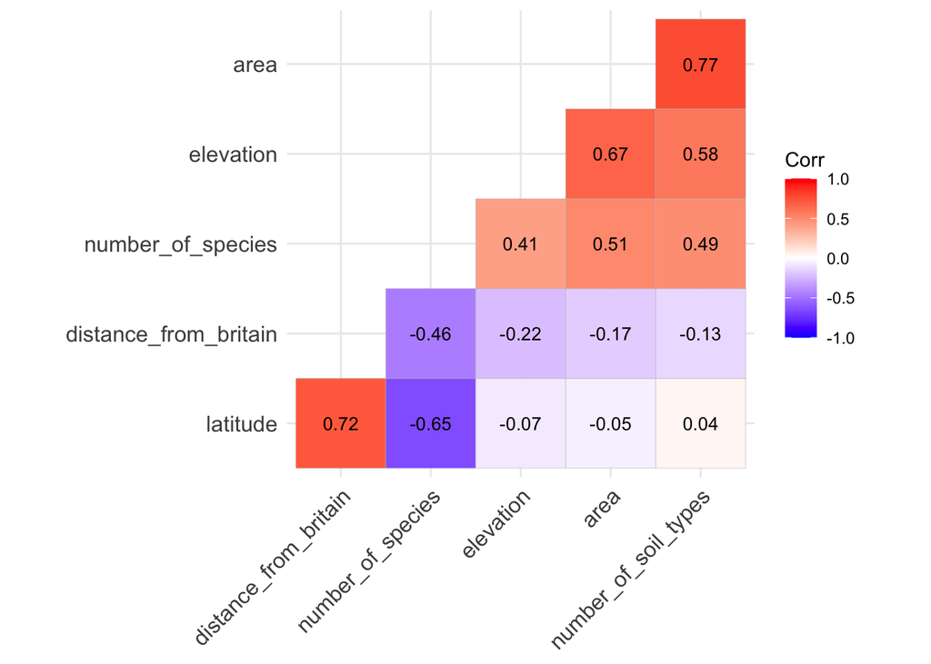

```r
# Verifcando correlação
ggcorrplot(
  cor(dados),
  hc.order = TRUE,
  type = "lower",
  lab = TRUE,
  lab_size = 3.5
)
```

# Modelo

## Criando modelos de RLM

```r
# Criando modelos para ajuste
modelo0 <- lm(number_of_species ~ 1, data = dados)
modelo1 <- lm(number_of_species ~ latitude + elevation + number_of_soil_types + latitude * number_of_soil_types, data = dados)
modelo2 <- lm(number_of_species ~ ., data = dados)

# Coletando informações de ajustes dos modelos
fit0 <- summary(modelo0)
fit1 <- summary(modelo1)
fit2 <- summary(modelo2)

# Tabulado resultado R2 e R2_Ajustado
R2 <- c(fit0$r.squared, fit1$r.squared, fit2$r.squared)
R2_ajustado <- c(fit0$adj.r.squared, fit1$adj.r.squared, fit2$adj.r.squared)
Modelo <- paste("Modelo", 0:2)
gof <- cbind(R2, R2_ajustado)
rownames(gof) <- Modelo

gof
```

```
##                 R2 R2_ajustado
## Modelo 0 0.0000000   0.0000000
## Modelo 1 0.7830798   0.7559648
## Modelo 2 0.7298113   0.6862324
```

O modelo0 e um modelo para média e o modelo1 apresentaram melhores resultados iniciais, onde foi incluido algumas variáveis, já no modelo2 onde incluimos todas às variáveis não performou bem. Verificando o summary do modelo1 podemos ter algumas estatísticas.

```r
# Resumo Modelo 01
summary(modelo1)
```

```
##
## Call:
## lm(formula = number_of_species ~ latitude + elevation + number_of_soil_types +
##     latitude * number_of_soil_types, data = dados)
##
## Residuals:
##      Min       1Q   Median       3Q      Max
## -233.740  -76.202    6.917   60.326  197.023
##
## Coefficients:
##                                 Estimate Std. Error t value Pr(>|t|)
## (Intercept)                    702.74391  922.44066   0.762 0.451740
## latitude                        -9.50790   15.99091  -0.595 0.556304
## elevation                       -0.02387    0.08565  -0.279 0.782278
## number_of_soil_types          1394.03102  377.63410   3.691 0.000826 ***
## latitude:number_of_soil_types  -22.67871    6.45544  -3.513 0.001344 **
## ---
## Signif. codes:  0 '***' 0.001 '**' 0.01 '*' 0.05 '.' 0.1 ' ' 1
##
## Residual standard error: 108.2 on 32 degrees of freedom
## Multiple R-squared:  0.7831, Adjusted R-squared:  0.756
## F-statistic: 28.88 on 4 and 32 DF,  p-value: 3.251e-10
```

## Seleção de Variáveis

Encontando o que poderia ser o melhor modelo utilizando técnicas de seleção de variáveis como AIC e BIC. Utilizando o modelo2 e deixar que o algoritimo escolha dentre todoas às variáveis, às melhores preditoras para o modelo.

### AIC

Passando modelo2 com todas às variáveis

```r
m_x1 <- step(modelo2, direction = "both")
```

```
## Start:  AIC=361.37
## number_of_species ~ area + elevation + number_of_soil_types +
##     latitude + distance_from_britain
##
##                         Df Sum of Sq    RSS    AIC
## - elevation              1      5709 472421 359.82
## - area                   1     11178 477890 360.25
## <none>                               466712 361.37
## - distance_from_britain  1     39344 506056 362.37
## - number_of_soil_types   1    105534 572246 366.92
## - latitude               1    528032 994744 387.37
##
## Step:  AIC=359.82
## number_of_species ~ area + number_of_soil_types + latitude +
##     distance_from_britain
##
##                         Df Sum of Sq    RSS    AIC
## - area                   1     22582 495004 359.55
## <none>                               472421 359.82
## - distance_from_britain  1     35952 508373 360.54
## + elevation              1      5709 466712 361.37
## - number_of_soil_types   1    114152 586573 365.83
## - latitude               1    523573 995995 385.42
##
## Step:  AIC=359.55
## number_of_species ~ number_of_soil_types + latitude + distance_from_britain
##
##                         Df Sum of Sq     RSS    AIC
## <none>                                495004 359.55
## + area                   1     22582  472421 359.82
## - distance_from_britain  1     35124  530128 360.09
## + elevation              1     17114  477890 360.25
## - number_of_soil_types   1    494776  989780 383.19
## - latitude               1    543854 1038857 384.98
```

```r
summary(m_x1)
```

```
##
## Call:
## lm(formula = number_of_species ~ number_of_soil_types + latitude +
##     distance_from_britain, data = dados)
##
## Residuals:
##     Min      1Q  Median      3Q     Max
## -342.95  -38.79   16.21   55.22  196.49
##
## Coefficients:
##                        Estimate Std. Error t value Pr(>|t|)
## (Intercept)           4371.2995   679.7160   6.431 2.73e-07 ***
## number_of_soil_types    82.0375    14.2842   5.743 2.06e-06 ***
## latitude               -73.8814    12.2699  -6.021 9.06e-07 ***
## distance_from_britain    0.5711     0.3732   1.530    0.135
## ---
## Signif. codes:  0 '***' 0.001 '**' 0.01 '*' 0.05 '.' 0.1 ' ' 1
##
## Residual standard error: 122.5 on 33 degrees of freedom
## Multiple R-squared:  0.7134, Adjusted R-squared:  0.6874
## F-statistic: 27.39 on 3 and 33 DF,  p-value: 4.433e-09
```

### BIC

```r
m_x2 <- step(modelo2, direction = "both", k = log(nrow(dados)))
```

```
## Start:  AIC=371.04
## number_of_species ~ area + elevation + number_of_soil_types +
##     latitude + distance_from_britain
##
##                         Df Sum of Sq    RSS    AIC
## - elevation              1      5709 472421 367.88
## - area                   1     11178 477890 368.30
## - distance_from_britain  1     39344 506056 370.42
## <none>                               466712 371.04
## - number_of_soil_types   1    105534 572246 374.97
## - latitude               1    528032 994744 395.43
##
## Step:  AIC=367.88
## number_of_species ~ area + number_of_soil_types + latitude +
##     distance_from_britain
##
##                         Df Sum of Sq    RSS    AIC
## - area                   1     22582 495004 366.00
## - distance_from_britain  1     35952 508373 366.98
## <none>                               472421 367.88
## + elevation              1      5709 466712 371.04
## - number_of_soil_types   1    114152 586573 372.28
## - latitude               1    523573 995995 391.87
##
## Step:  AIC=366
## number_of_species ~ number_of_soil_types + latitude + distance_from_britain
##
##                         Df Sum of Sq     RSS    AIC
## - distance_from_britain  1     35124  530128 364.92
## <none>                                495004 366.00
## + area                   1     22582  472421 367.88
## + elevation              1     17114  477890 368.30
## - number_of_soil_types   1    494776  989780 388.02
## - latitude               1    543854 1038857 389.81
##
## Step:  AIC=364.92
## number_of_species ~ number_of_soil_types + latitude
##
##                         Df Sum of Sq     RSS    AIC
## <none>                                530128 364.92
## + distance_from_britain  1     35124  495004 366.00
## + area                   1     21754  508373 366.98
## + elevation              1     10913  519215 367.76
## - number_of_soil_types   1    460342  990470 384.44
## - latitude               1    779158 1309286 394.76
```

```r
summary(m_x2)
```

```
##
## Call:
## lm(formula = number_of_species ~ number_of_soil_types + latitude,
##     data = dados)
##
## Residuals:
##     Min      1Q  Median      3Q     Max
## -309.56  -48.05   18.02   72.48  196.21
##
## Coefficients:
##                      Estimate Std. Error t value Pr(>|t|)
## (Intercept)          3631.647    487.222   7.454 1.20e-08 ***
## number_of_soil_types   77.008     14.173   5.434 4.69e-06 ***
## latitude              -60.110      8.503  -7.069 3.65e-08 ***
## ---
## Signif. codes:  0 '***' 0.001 '**' 0.01 '*' 0.05 '.' 0.1 ' ' 1
##
## Residual standard error: 124.9 on 34 degrees of freedom
## Multiple R-squared:  0.6931, Adjusted R-squared:  0.675
## F-statistic: 38.39 on 2 and 34 DF,  p-value: 1.901e-09
```

## Análises dos Modelos

O metodo de seleção **BIC** apontou como sendo as melhores variáveis a `latitude` e `number_of_soil_types`. Analisando os modelos criados, neste caso o modelo1.

Análise de resíduo do modelo

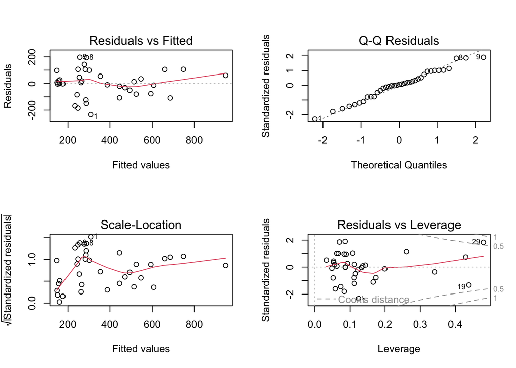

```r
# Gráficos residuais, para análise
par(mfrow = c(2, 2))
plot(modelo1)
```

A diferença encontrada entre o `R2` e `R2_Ajustado` do modelo1 indica que podemos ter uma questão de multicolinariedade e o que o gráfico de `Standardized residuals vs Fitted values` nos mostra uma possivél fuga da suposição de Gausianidade dos dados.

```r
# Teste de siguinificancia da regresão
anova(modelo0, modelo1)
```

|  | Res.Df | RSS | Df | Sum of Sq | F | Pr(>F) |
| --- | --- | --- | --- | --- | --- | --- |
| 1 | 36 | 1727356.1 | NA | NA | NA | NA |
| 2 | 32 | 374698.4 | 4 | 1352658 | 28.87992 | 3.251428e-10 |

```r
anova(modelo1)
```

|  | Df | Sum Sq | Mean Sq | F value | Pr(>F) |
| --- | --- | --- | --- | --- | --- |
| latitude | 1 | 736885.9 | 736885.91 | 62.93154 | 4.707526e-09 |
| elevation | 1 | 232727.1 | 232727.15 | 19.87537 | 9.520374e-05 |
| number_of_soil_types | 1 | 238528.1 | 238528.14 | 20.37078 | 8.123459e-05 |
| latitude:number_of_soil_types | 1 | 144516.5 | 144516.50 | 12.34200 | 1.344140e-03 |
| Residuals | 32 | 374698.4 | 11709.33 | NA | NA |

```r
drop1(modelo1, test = "F")
```

|  | Df | Sum of Sq | RSS | AIC | F value | Pr(>F) |
| --- | --- | --- | --- | --- | --- | --- |
|  | NA | NA | 374698.4 | 351.2495 | NA | NA |
| elevation | 1 | 909.4189 | 375607.8 | 349.3392 | 0.0776662 | 0.78227845 |
| latitude:number_of_soil_types | 1 | 144516.4972 | 519214.9 | 361.3187 | 12.3420003 | 0.00134414 |

# Ajustando Modelo

Como no teste `F drop1` demostrou que a variável elevation não seria sigunificante, irei retirar e ver o resultado.

```r
m0 <- lm(number_of_species ~ latitude + number_of_soil_types + latitude * number_of_soil_types, data = dados)
summary(m0)
```

```
##
## Call:
## lm(formula = number_of_species ~ latitude + number_of_soil_types +
##     latitude * number_of_soil_types, data = dados)
##
## Residuals:
##      Min       1Q   Median       3Q      Max
## -238.676  -82.769    4.352   69.621  194.472
##
## Coefficients:
##                               Estimate Std. Error t value Pr(>|t|)
## (Intercept)                     765.00     882.39   0.867 0.392223
## latitude                        -10.61      15.27  -0.695 0.491915
## number_of_soil_types           1356.16     347.38   3.904 0.000442 ***
## latitude:number_of_soil_types   -22.07       5.99  -3.685 0.000816 ***
## ---
## Signif. codes:  0 '***' 0.001 '**' 0.01 '*' 0.05 '.' 0.1 ' ' 1
##
## Residual standard error: 106.7 on 33 degrees of freedom
## Multiple R-squared:  0.7826, Adjusted R-squared:  0.7628
## F-statistic: 39.59 on 3 and 33 DF,  p-value: 4.868e-11
```

Pode-se obesevar um pequeno ganho no R_Ajustado com a remoção da variável elevation,

## Medidas de Influência

```r
influ <- influence.measures(m0)
summary(influ)
```

```
## Potentially influential observations of
##   lm(formula = number_of_species ~ latitude + number_of_soil_types +      latitude * number_of_soil_types, data = dados) :
##
##    dfb.1_  dfb.lttd dfb.n___ dfb.l:__ dffit   cov.r   cook.d hat
## 1  -0.61    0.59     0.50    -0.48    -0.84    0.60_*  0.15   0.10
## 19 -1.12_*  1.11_*   0.86    -0.86    -1.21_*  1.58_*  0.35   0.43_*
## 25 -0.04    0.04     0.06    -0.06    -0.14    1.52_*  0.01   0.26
## 29  0.90   -0.92    -1.28_*   1.32_*   1.87_*  1.39_*  0.81   0.48_*
## 36 -0.06    0.06     0.31    -0.31     0.56    1.57_*  0.08   0.33_*
```

```r
# Removendo obeservações influentes dffit
dfits <- influ$is.inf[, 4]
id <- which(dfits)

# Atualizando modelo com retira das observação
m1 <- update(m0, data = dados[-id,])
summary(m1)
```

```
##
## Call:
## lm(formula = number_of_species ~ latitude + number_of_soil_types +
##     latitude * number_of_soil_types, data = dados[-id, ])
##
## Residuals:
##     Min      1Q  Median      3Q     Max
## -230.66  -77.86    5.75   60.10  197.81
##
## Coefficients:
##                               Estimate Std. Error t value Pr(>|t|)
## (Intercept)                      5.647    932.055   0.006 0.995203
## latitude                         2.841     16.199   0.175 0.861877
## number_of_soil_types          1784.404    399.129   4.471 9.18e-05 ***
## latitude:number_of_soil_types  -29.684      6.947  -4.273 0.000162 ***
## ---
## Signif. codes:  0 '***' 0.001 '**' 0.01 '*' 0.05 '.' 0.1 ' ' 1
##
## Residual standard error: 102.4 on 32 degrees of freedom
## Multiple R-squared:  0.8054, Adjusted R-squared:  0.7871
## F-statistic: 44.13 on 3 and 32 DF,  p-value: 1.771e-11
```

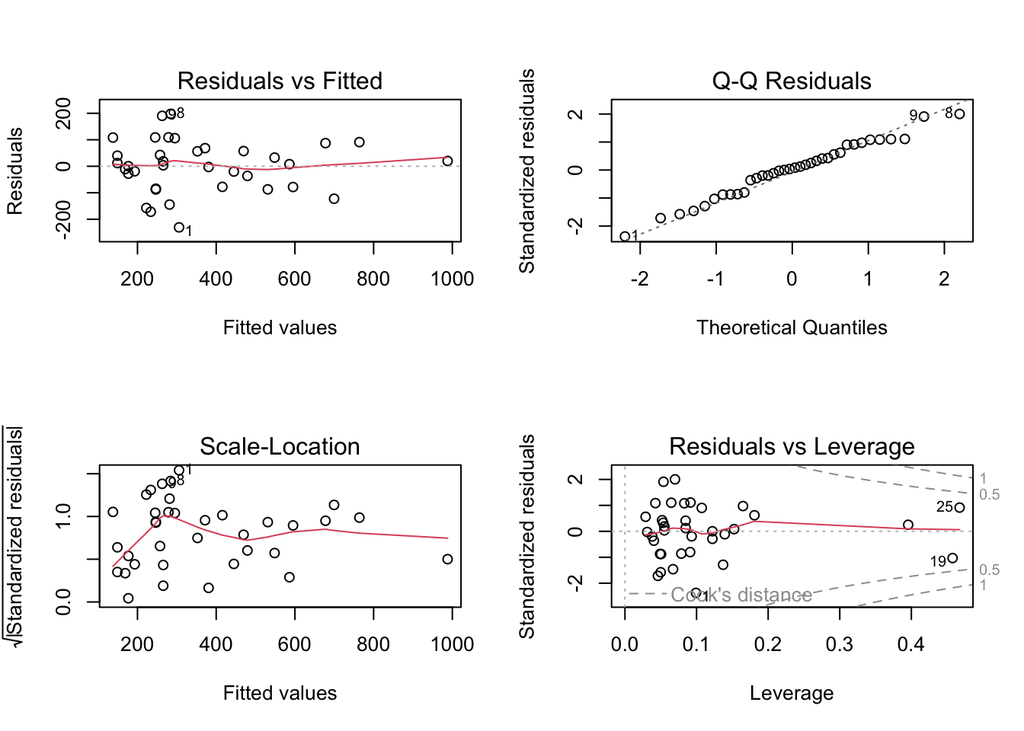

```r
# Gráficos residuais, para análise
par(mfrow = c(2, 2))
plot(m1)
```

```r
#
car::vif(m1)
```

```
##                      latitude          number_of_soil_types
##                      5.164857                    966.597144
## latitude:number_of_soil_types
##                    963.205714
```

Alterando modelo.

```r
m2 <- lm(number_of_species ~ latitude + sqrt(number_of_soil_types) + latitude * sqrt(number_of_soil_types), data = dados)
summary(m2)
```

```
##
## Call:
## lm(formula = number_of_species ~ latitude + sqrt(number_of_soil_types) +
##     latitude * sqrt(number_of_soil_types), data = dados)
##
## Residuals:
##     Min      1Q  Median      3Q     Max
## -230.51  -74.96   11.97   55.40  201.50
##
## Coefficients:
##                                     Estimate Std. Error t value Pr(>|t|)
## (Intercept)                         -1829.94    1566.46  -1.168 0.251096
## latitude                               31.40      27.18   1.155 0.256348
## sqrt(number_of_soil_types)           3864.68    1045.21   3.698 0.000787 ***
## latitude:sqrt(number_of_soil_types)   -62.67      18.12  -3.458 0.001520 **
## ---
## Signif. codes:  0 '***' 0.001 '**' 0.01 '*' 0.05 '.' 0.1 ' ' 1
##
## Residual standard error: 106.5 on 33 degrees of freedom
## Multiple R-squared:  0.7834, Adjusted R-squared:  0.7637
## F-statistic: 39.78 on 3 and 33 DF,  p-value: 4.571e-11
```

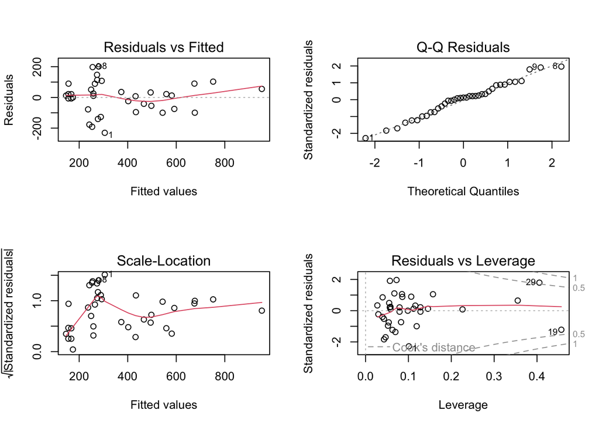

```r
# Gráficos residuais, para análise
par(mfrow = c(2, 2))
plot(m2)
```

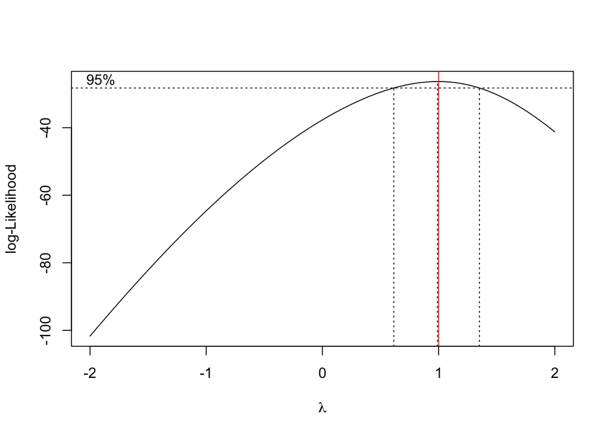

```r
#
MASS::boxcox(m2)
abline(v = 1, col = "red")
```

```r
car::vif(m2)
```

```
##                            latitude          sqrt(number_of_soil_types)
##                            14.07065                           724.82076
## latitude:sqrt(number_of_soil_types)
##                           741.09163
```

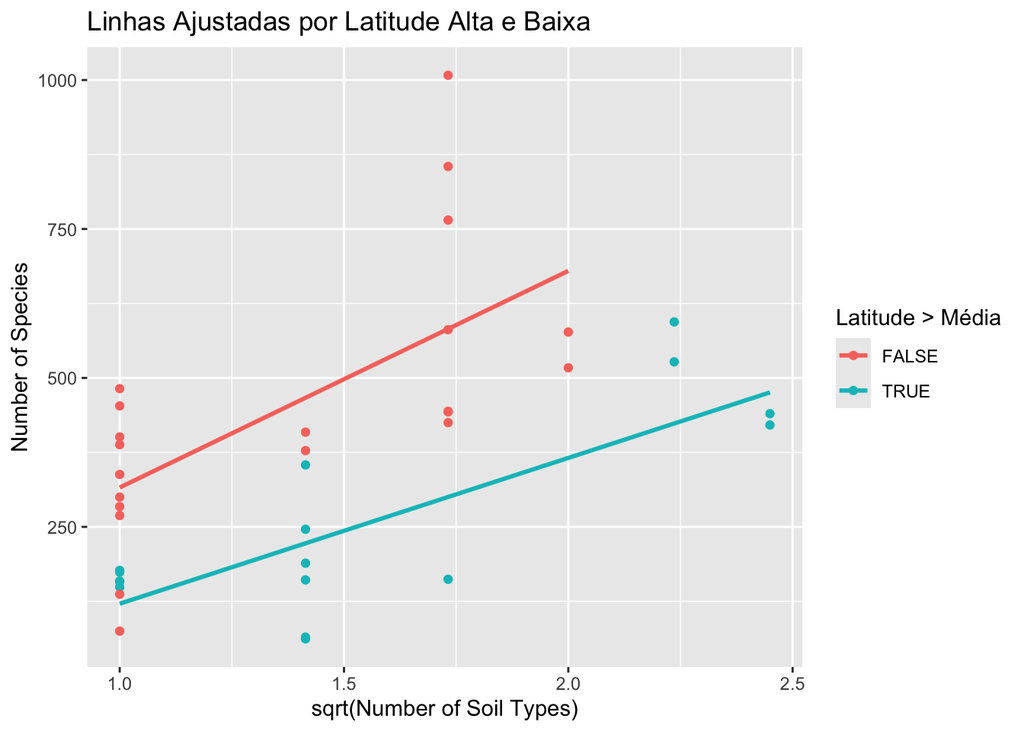

```r
# Gráfico de Linhas Ajustadas por Grupos
# Usando ggplot2 para ajustar linhas para diferentes grupos de latitude
ggplot(dados, aes(x = sqrt(number_of_soil_types), y = number_of_species, color = factor(latitude > mean(latitude)))) +
  geom_point() +
  geom_smooth(method = "lm", se = FALSE) +
  labs(title = "Linhas Ajustadas por Latitude Alta e Baixa",
       x = "sqrt(Number of Soil Types)",
       y = "Number of Species",
       color = "Latitude > Média")
```

```r
# Gráfico de Regressão Parcial (Added Variable Plot)
# Os gráficos de variáveis adicionadas mostram o efeito de uma variável explicativa, considerando as outras já no modelo.
#avPlots(m2)
```

```r
# Obter os valores preditos
v_pretitos_m1 <- predict(m1)
v_pretitos_m2 <- predict(m2)

# Calcular o erro quadrático
erro_quadratico_m1 <- (dados$number_of_species - v_pretitos_m1)^2
erro_quadratico_m2 <- (dados$number_of_species - v_pretitos_m2)^2

# Calcular o RMSE
rmse_m1 <- sqrt(mean(erro_quadratico_m1))
rmse_m2 <- sqrt(mean(erro_quadratico_m2))

# Mostrar o resultado
cat("RMSE m1:", rmse_m1, "\n")
```

```
## RMSE m1: 235.0594
```

```r
cat("RMSE m2:", rmse_m2, "\n")
```

```
## RMSE m2: 100.5611
```

## Regressão Ridge

Visualizar os coeficientes: Você pode visualizar os coeficientes do modelo em diferentes valores de lambda.

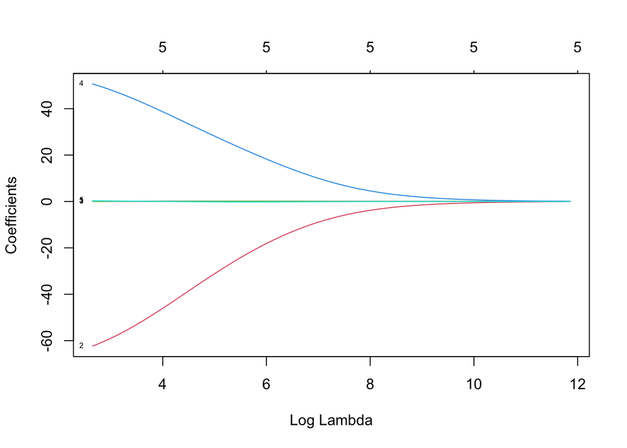

```r
# Preparando variáveis independentes (como uma matriz) e a variável dependente.
x <- as.matrix(dados[, c("area", "latitude", "elevation", "number_of_soil_types", "distance_from_britain")])
y <- dados$number_of_species

# Ajustar o modelo Ridge
m4 <- glmnet(x, y, alpha = 0)

# Visualizar os coeficientes
plot(m4, xvar = "lambda", label = TRUE)
```

Selecionar o melhor lambda: Para selecionar o valor de lambda que minimiza o erro, pode-se usar a validação cruzada com a função `cv.glmnet()`.

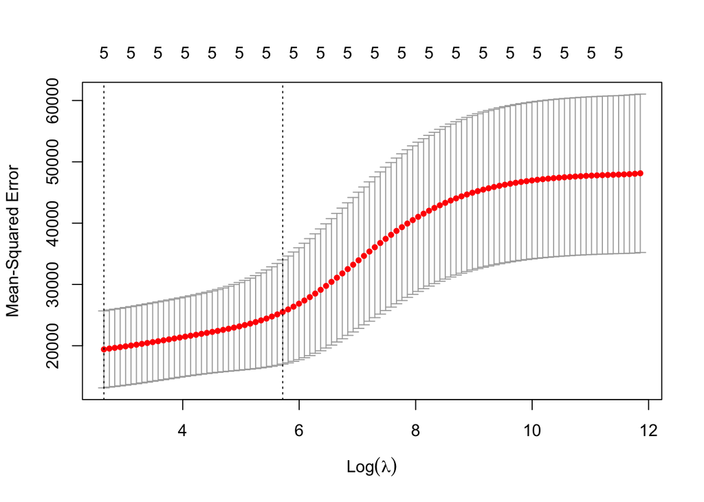

```r
# Validação cruzada para escolher o melhor lambda
cv_ridge <- cv.glmnet(x, y, alpha = 0)

# Melhor lambda
melhor_lambda <- cv_ridge$lambda.min

# Visualizar o resultado da validação cruzada
plot(cv_ridge)
```

Ajustar o modelo final com o melhor lambda: Após identificar o melhor lambda, você pode ajustar o modelo final.

```r
# Ajustar o modelo final com o melhor lambda
modelo_final <- glmnet(x, y, alpha = 0, lambda = melhor_lambda)

# Coeficientes finais
coeficientes_finais <- coef(modelo_final)
print(coeficientes_finais)
```

```
## 6 x 1 sparse Matrix of class "dgCMatrix"
##                                  s0
## (Intercept)           3757.00256100
## area                     0.07421104
## latitude               -62.37017984
## elevation                0.06231436
## number_of_soil_types    50.68202835
## distance_from_britain    0.34389328
```

```r
# Fazer predições
predicoes <- predict(modelo_final, newx = x)

# Calcular RMSE
rmse <- sqrt(mean((y - predicoes)^2))

# Calcular MAE
mae <- mean(abs(y - predicoes))

# Mostrar os resultados
cat("RMSE:", rmse, "\n")
```

```
## RMSE: 113.8269
```

```r
cat("MAE:", mae, "\n")
```

```
## MAE: 82.54097
```